# Worked Example: Lizard Sprint Speed/Tick Parasitism

1. Is there a relationship between hind limb length (HLL) and sprint performance (Max_25cm or Max_2m)? Is this better described by a traditional linear model (OLS) or by a GLM with some other specified error and ‘link’ functions? POISSON ONLY REALLY SUITABLE FOR RESPONSE DATA THAT ARE COUNTS, but OK.
2. Does level of parasitism (#ticks) modify the relationship between hind limb length (HLL) and sprint performance (Max_25cm or Max_2m)?
3. Is sprint speed different between treatments after accounting for both hind limb length (HLL) AND level of parasitism (#ticks)? (hint: use library(emmeans) for pairwise comparisons of covariate-adjusted means)

```r
library(readr)
lizard_sprint <- read_csv("lizard_sprint_tick.csv")
sprint.poisson <- glm(Max_2m~HLL, family= poisson(link=log), data= lizard_sprint)
sprint.ols <- glm(Max_2m~HLL, family= gaussian(link=identity), data= lizard_sprint)
#sprint.gamma <- glm(Max_2m~HLL, family=Gamma(link= "sqrt"), data= lizard_sprint)
anova(sprint.poisson,sprint.ols, test = "Chisq")
```

```
Analysis of Deviance Table

Model 1: Max_2m ~ HLL
Model 2: Max_2m ~ HLL
  Resid. Df Resid. Dev Df Deviance Pr(>Chi)
1        49     4.5826
2        49     7.7136  0  -3.1309
```

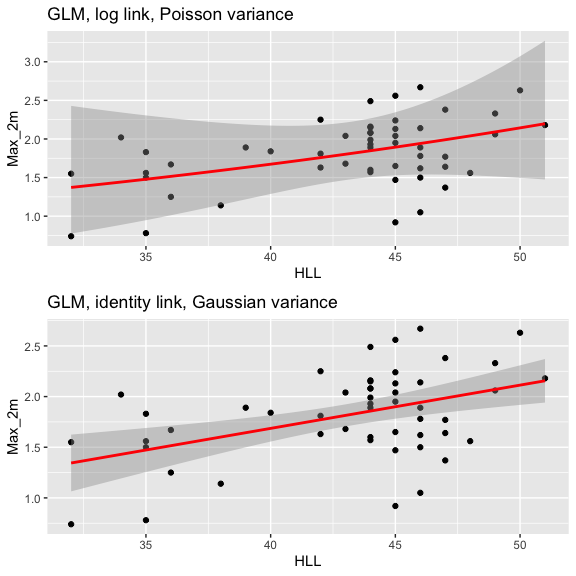

```r
p1 <- ggplot(lizard_sprint,aes(HLL,Max_2m))+geom_point() +
  geom_smooth(method="glm",colour="red",
                         method.args=list(family="poisson"(link="log")))+
  labs(title="GLM, log link, Poisson variance")
p2 <- ggplot(lizard_sprint,aes(HLL,Max_2m))+geom_point() +
  geom_smooth(method="glm",colour="red",
                         method.args=list(family="gaussian"(link="identity")))+
  labs(title="GLM, identity link, Gaussian variance")
#p3 <-ggplot(lizard_sprint,aes(HLL,Max_2m))+geom_point() +
  #geom_smooth(method="glm",colour="red",
                         #method.args=list(family="Gamma"(link="sqrt")))+
  #labs(title="GLM, square-root link, Gamma variance")
grid.arrange(p1, p2, ncol=1)
```

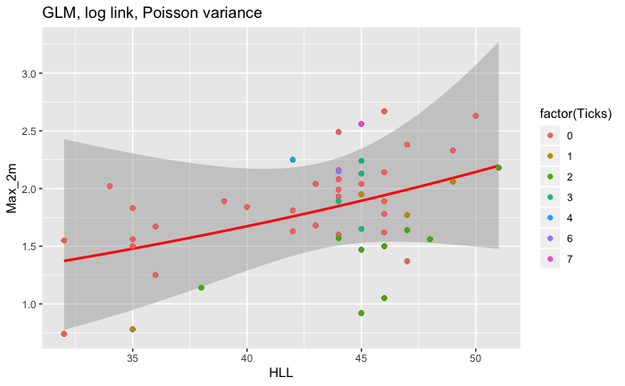

```r
p1+geom_point(aes(colour = factor(Ticks)))
```

```r
sprint.poisson.ticks <- glm(Max_2m~HLL+factor(Ticks), family= poisson(link=log), data= lizard_sprint)
anova(sprint.poisson.ticks)
```

```
Analysis of Deviance Table

Model: poisson, link: log

Response: Max_2m

Terms added sequentially (first to last)

              Df Deviance Resid. Df Resid. Dev
NULL                             50     5.7348
HLL            1   1.1522        49     4.5826
factor(Ticks)  6   1.9992        43     2.5834
```

```r
sprint.fullmodel.poi <- glm(Max_2m~Site+HLL+factor(Ticks), family= gaussian(link=identity), data= lizard_sprint)
anova(sprint.fullmodel)
summary(sprint.fullmodel)
```

[output not shown]

THIS WOULD HAVE BEEN A FAR BETTER QUESTION. Does Increased body size (age) mean higher tick load?

```
Call:
glm(formula = as.numeric(Ticks) ~ SVL, family = poisson(link = log),
    data = lizard_sprint)

Deviance Residuals:
    Min       1Q   Median       3Q      Max
-1.8183  -1.3843  -0.9376   0.5605   3.4779

Coefficients:
            Estimate Std. Error z value Pr(>|z|)
(Intercept) -5.02967    1.72613  -2.914  0.00357 **
SVL          0.07792    0.02611   2.984  0.00285 **
---
Signif. codes:  0 ‘***’ 0.001 ‘**’ 0.01 ‘*’ 0.05 ‘.’ 0.1 ‘ ’ 1

(Dispersion parameter for poisson family taken to be 1)

    Null deviance: 111.15  on 50  degrees of freedom
Residual deviance: 100.56  on 49  degrees of freedom
AIC: 158.78

Number of Fisher Scoring iterations: 6
```

Interpretation?

```
[1] 1.081036
```

[figure not shown]

[figure not shown]

TRY AGAIN